# Site Report

DataSciT39

Tuesday-22-Dec-2020

# Site Report for Dates 01092020 to 01092020.

## All Site Types: Empty API Responses

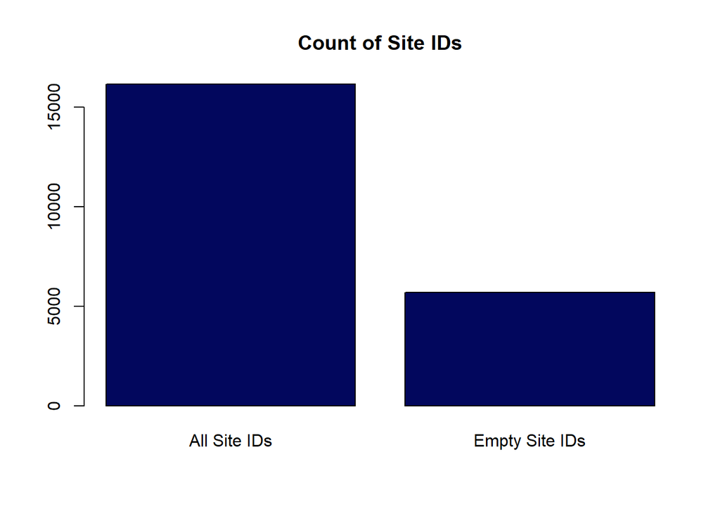

There were **16,165** site IDs queried in total.

Of these IDs, **5,686** of the queries returned **no content** (HTTP response [code 204](https://httpstatuses.com/204)).

This means that **35 % (rounded)** of the IDs contained no content for this date range.

## Empty Responses by Site Type

### MIDAS

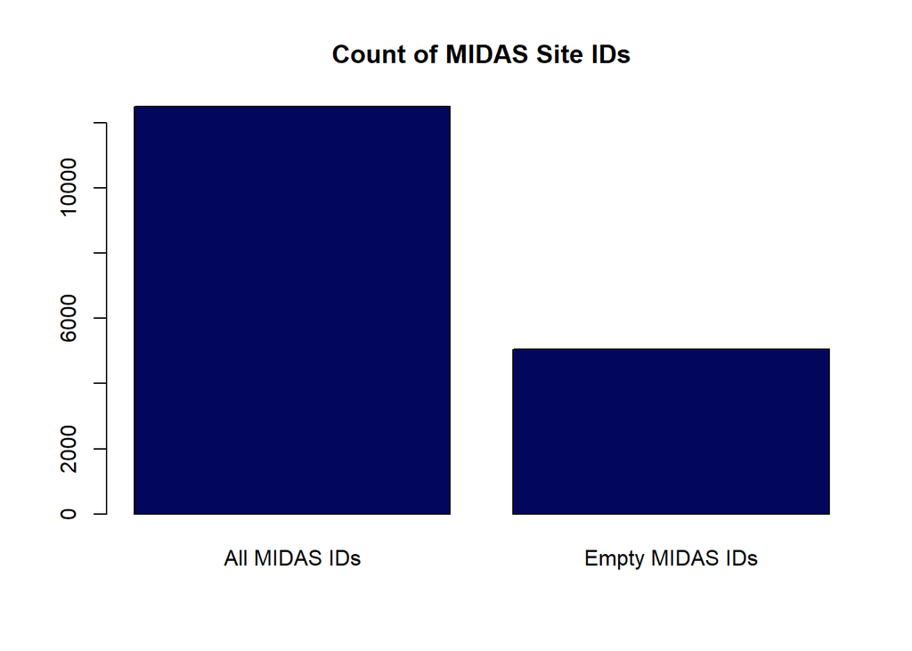

There were **12,499** site IDs of the MIDAS type.

Of these IDs, **5,042** of the queries returned **no content** (HTTP response [code 204](https://httpstatuses.com/204)).

This means that **40 % (rounded)** of the MIDAS IDs contained no content for this date range.

#### Empty Responses: MIDAS Site Details

| row_count | sites.Id | sites.Name | sites.Description | sites.Status | type |
| --- | --- | --- | --- | --- | --- |
| 12499 | 1 | MIDAS site at M4/2295A2 priority 1 on link 105009001; GPS Ref: 502816;178156; Westbound | M4/2295A2 | Inactive | midas |
| 12499 | 6 | MIDAS site at M27/9273A priority 1 on link 103009302; GPS Ref: 448516;111110; Eastbound | M27/9273A | Inactive | midas |
| 12499 | 9 | MIDAS site at M60/9164M priority 1 on link 115021301; GPS Ref: 376508;396448; Anti-clockwise | M60/9164M | Inactive | midas |
| 12499 | 10 | MIDAS site at M62/1686A priority 1 on link 125025001; GPS Ref: 393066;411906; Eastbound | M62/1686A | Inactive | midas |
| 12499 | 11 | MIDAS site at M27/9387A priority 1 on link 103010501; GPS Ref: 458731;107342; Eastbound | M27/9387A | Inactive | midas |
| 12499 | 12 | MIDAS site at M6/6760B priority 1 on link 110005801; GPS Ref: 374505;366313; Southbound | M6/6760B | Inactive | midas |
| 12499 | 16 | MIDAS site at M2/8460A priority 1 on link 200006989; GPS Ref: 571654;168165; Eastbound | M2/8460A | Inactive | midas |
| 12499 | 27 | MIDAS site at M1/2771A priority 1 on link 108020101; GPS Ref: 492031;239267; Northbound | M1/2771A | Inactive | midas |
| 12499 | 37 | MIDAS site at M1/4623A priority 1 on link 116025801; GPS Ref: 438610;392803; Northbound | M1/4623A | Inactive | midas |
| 12499 | 50 | MIDAS site at M5/9061A priority 1 on link 102033901; GPS Ref: 325860;125311; Southbound | M5/9061A | Inactive | midas |

[output cut: 5032 more lines]

### TAME

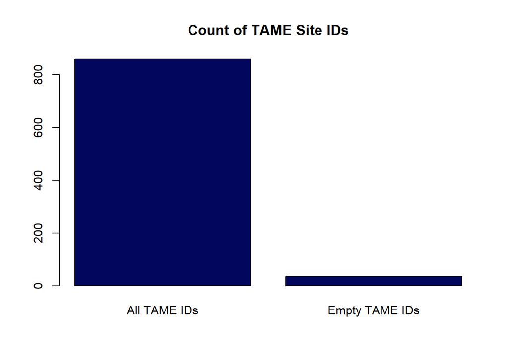

There were **859** site IDs of the TAME type.

Of these IDs, **35** of the queries returned **no content** (HTTP response [code 204](https://httpstatuses.com/204)).

This means that **4 % (rounded)** of the TAME IDs contained no content for this date range.

#### Empty Responses: TAME Site Details

| row_count | sites.Id | sites.Name | sites.Description | sites.Status | type |
| --- | --- | --- | --- | --- | --- |
| 859 | 6437 | TAME Site 30360097 on link M5 northbound between J14 and J13; GPS Ref: 372599;199140; Northbound | 30360097 | Inactive | tame |
| 859 | 6438 | TAME Site 30360098 on link M5 southbound between J13 and J14; GPS Ref: 372611;199029; Southbound | 30360098 | Inactive | tame |
| 859 | 6446 | TAME Site 30360114 on link M5 southbound between J17 and J18; GPS Ref: 356550;180579; Southbound | 30360114 | Inactive | tame |
| 859 | 6544 | TAME Site 30360695 on link A120 westbound at a minor junction between B1256 near Great Dunmow (west) and M11; GPS Ref: 553800;221803; Westbound | 30360695 | Inactive | tame |
| 859 | 6545 | TAME Site 30360696 on link A120 westbound access at a minor junction between B1256 near Great Dunmow (west) and M11; GPS Ref: 553802;221800; Westbound | 30360696 | Inactive | tame |
| 859 | 6640 | TAME Site 30360831 on link A421 northbound between A600 and A603; GPS Ref: 507840;248078; Northbound | 30360831 | Inactive | tame |
| 859 | 6641 | TAME Site 30360832 on link A421 southbound between A603 and A600; GPS Ref: 507852;248068; Southbound | 30360832 | Inactive | tame |
| 859 | 6642 | TAME Site 30360833 on link A5 northbound between B4100 and A4146 near Bletchley (south); GPS Ref: 490358;232873; Northbound | 30360833 | Inactive | tame |
| 859 | 6643 | TAME Site 30360834 on link A5 southbound between A4146 near Bletchley (south) and B4100; GPS Ref: 490360;232894; Southbound | 30360834 | Inactive | tame |
| 859 | 6656 | TAME Site 30360854 on link A14 eastbound between J22 and J23; GPS Ref: 521671;272167; Eastbound | 30360854 | Inactive | tame |

[output cut: 25 more lines]

### TMU

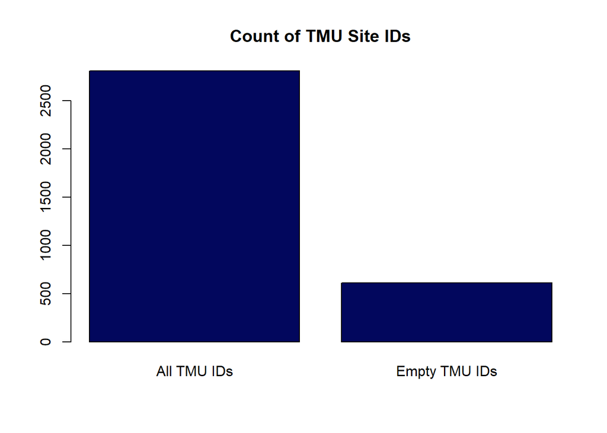

There were **2,807** site IDs of the TMU type.

Of these IDs, **609** of the queries returned **no content** (HTTP response [code 204](https://httpstatuses.com/204)).

This means that **22 % (rounded)** of the TMU IDs contained no content for this date range.

#### Empty Responses: TMU Site Details

| row_count | sites.Id | sites.Name | sites.Description | sites.Status | type |
| --- | --- | --- | --- | --- | --- |
| 2807 | 7265 | TMU Site 5669/2 on A34 southbound within the A4074/4183 junction; GPS Ref: 451141;203663; Southbound | 5669/2 | Inactive | tmu |
| 2807 | 7266 | TMU Site 5669/1 on A34 southbound exit for A4074/A4813; GPS Ref: 451152;203673; Southbound | 5669/1 | Inactive | tmu |
| 2807 | 7298 | TMU Site 5559/2 on M27 westbound within J12 before M275 access; GPS Ref: 464999;104648; Westbound | 5559/2 | Inactive | tmu |
| 2807 | 7299 | TMU Site 5559/1 on link link road from M27 J12 westbound to M275; GPS Ref: 465005;104624; Southbound | 5559/1 | Inactive | tmu |
| 2807 | 7305 | TMU Site 5556/2 on link M27 eastbound within J12 before A275 exit; GPS Ref: 463811;105286; Eastbound | 5556/2 | Inactive | tmu |
| 2807 | 7306 | TMU Site 5556/1 on link M27 J12 eastbound exit for A27; GPS Ref: 463824;105304; Eastbound | 5556/1 | Inactive | tmu |
| 2807 | 7307 | TMU Site 5555/2 on link M27 westbound within J11; GPS Ref: 459606;106967; Westbound | 5555/2 | Inactive | tmu |
| 2807 | 7308 | TMU Site 5555/1 on link M27 J11 westbound exit; GPS Ref: 459600;106947; Westbound | 5555/1 | Inactive | tmu |
| 2807 | 7309 | TMU Site 5554/1 on link M27 J11 eastbound exit; GPS Ref: 459188;107179; Eastbound | 5554/1 | Inactive | tmu |
| 2807 | 7449 | TMU Site 5319/1 on link M4 J19 eastbound exit; GPS Ref: 364081;179708; Eastbound | 5319/1 | Inactive | tmu |

[output cut: 599 more lines]

## Join Integrity (Coming Soon…)